# Todo lo que debes saber sobre funciones y gráficas en R

Emilio Olguín Monterrubio

12/9/2020

## A continuación vas a aprender a resolver funciones y graficarlas en R

El primer paso es definir un dominio para nuestra función

```r
x<-(-10:10)
```

El segundo paso es definir f(x)

```r
fx<-x+6*3
fx
```

```
##  [1]  8  9 10 11 12 13 14 15 16 17 18 19 20 21 22 23 24 25 26 27 28
```

Para graficar fx usamos plot y para que nos identifique los puntos escribimos “type=”o""como se ve a continuación

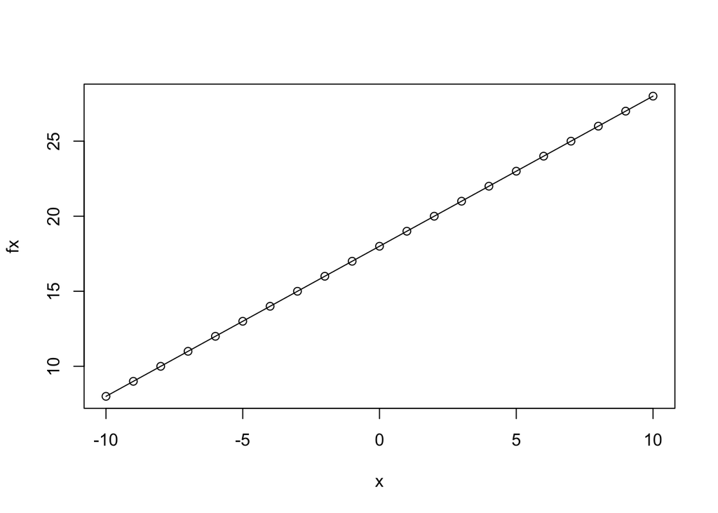

```r
plot(x,fx, type = "o")
```

También se pueden graficar funciones cuadráticas como lo haremos a continuación

```r
gx<-x^2+7
gx
```

```
##  [1] 107  88  71  56  43  32  23  16  11   8   7   8  11  16  23  32  43  56  71
## [20]  88 107
```

Como se hizo en la anterior función vamos a graficar con plot y usaremos otro tipo de gráfica ahora con type:“l”

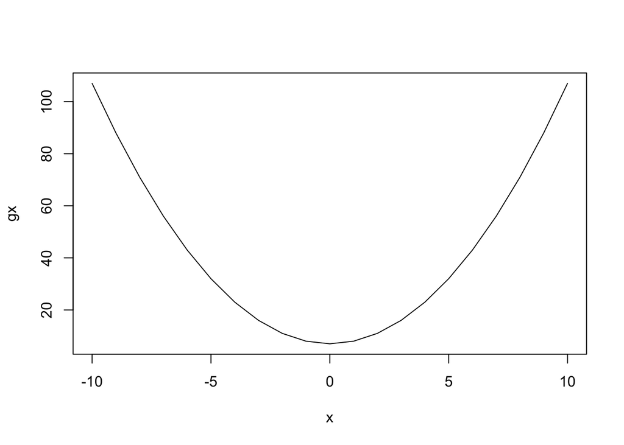

```r
plot(x,gx, type = "l")
```

También se pueden graficar funciones cúbicas

```r
ex<-x^3+2
ex
```

```
##  [1] -998 -727 -510 -341 -214 -123  -62  -25   -6    1    2    3   10   29   66
## [16]  127  218  345  514  731 1002
```

Y es el mismo procedimiento para graficar sólo que ahora cambiaremos el tipo de gráfica por una en la que sólo resalte los puntos, esto se logra con type=“p”

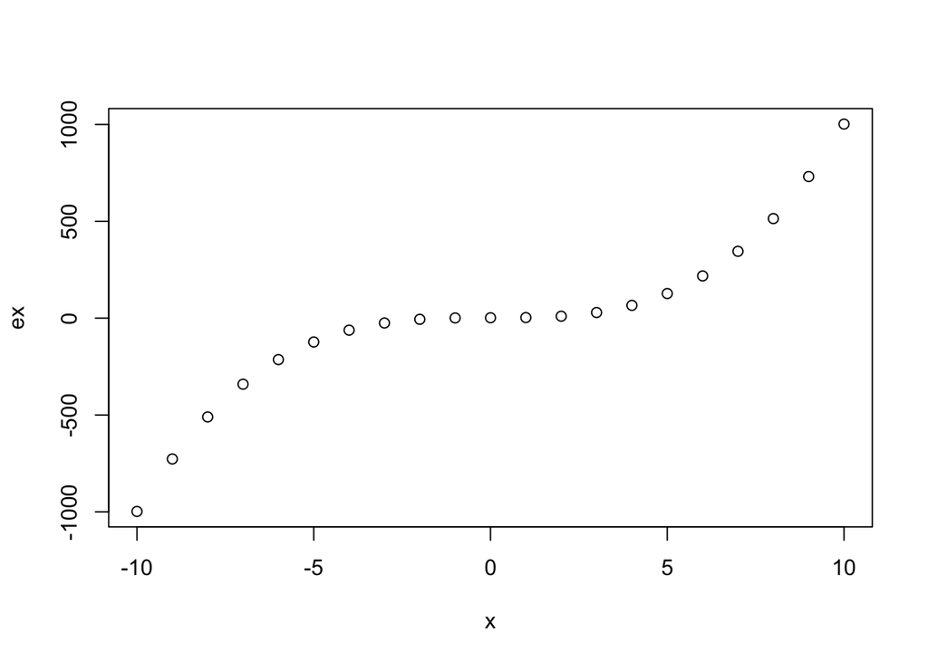

```r
plot(x, ex, type = "p")
```

También se le pueden poner color a las funciones como veremos a continuación

```r
ax<-x+5
ax
```

```
##  [1] -5 -4 -3 -2 -1  0  1  2  3  4  5  6  7  8  9 10 11 12 13 14 15
```

Ahora para graficar es el mismo procedimiento pero ahora le pondremos color

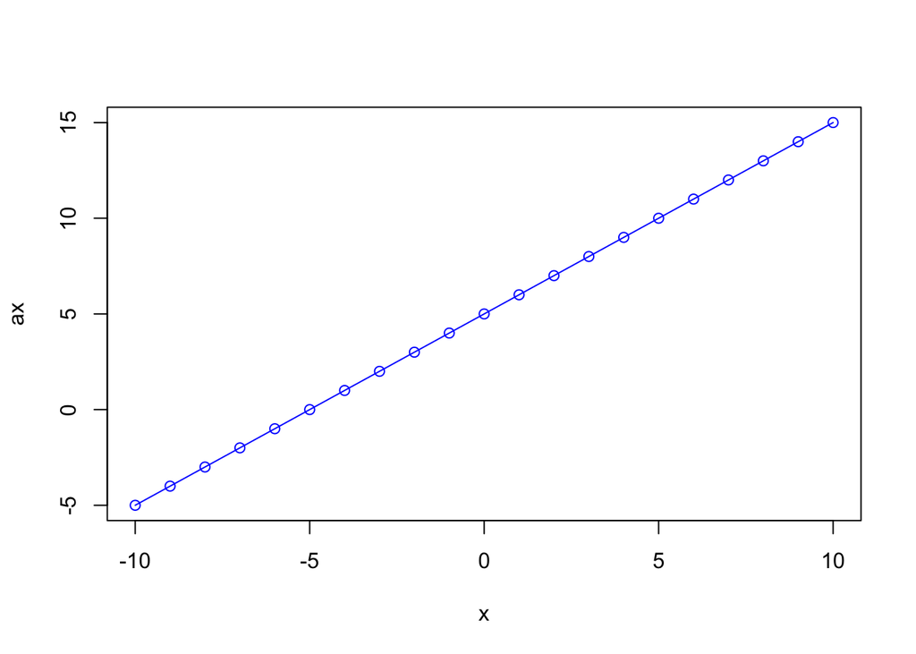

```r
plot(x,ax, type="o", col="blue")
```

# Operaciones con funciones

## También se pueden restar, sumar las funciones y graficar el resultado como lo haremos a continuación

Primero restaremos las funciones

```r
g_menos_f<-gx-fx
g_menos_f
```

```
##  [1]  99  79  61  45  31  19   9   1  -5  -9 -11 -11  -9  -5   1   9  19  31  45
## [20]  61  79
```

Después graficaremos el resultado con color

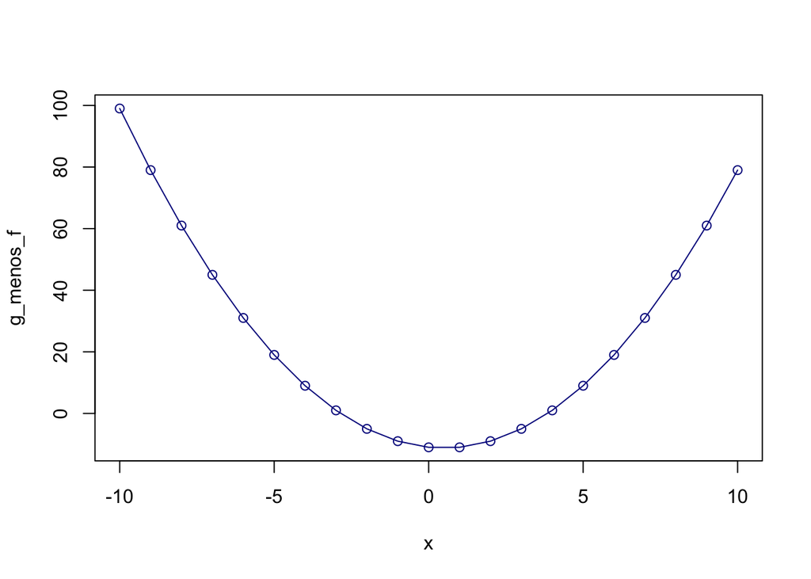

```r
plot(x, g_menos_f, type = "o", col="darkblue")
```

Ahora sumaremos las funciones

```r
e_mas_a<-ex+ax
e_mas_a
```

```
##  [1] -1003  -731  -513  -343  -215  -123   -61   -23    -3     5     7     9
## [13]    17    37    75   137   229   357   527   745  1017
```

Ahora sólo nos falta graficar y darle color

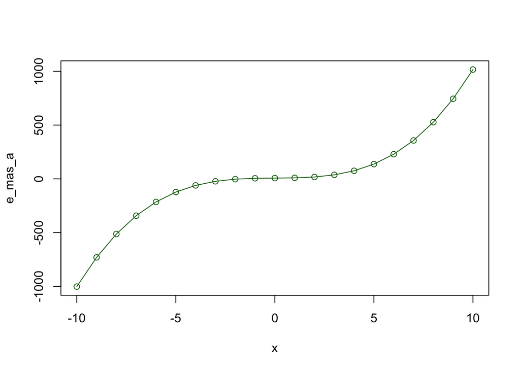

```r
plot(x, e_mas_a, type="o", col="darkgreen")
```

# Si quieres saber cómo hice éste código ve el siguiente video:

[video not shown]